# Final Proposal

Let’s focus our attention on a select subset of sectors:

- Professional, Scientific, and Technical Services
- Real Estate and Rental and Leasing
- Retail Trade
- Construction

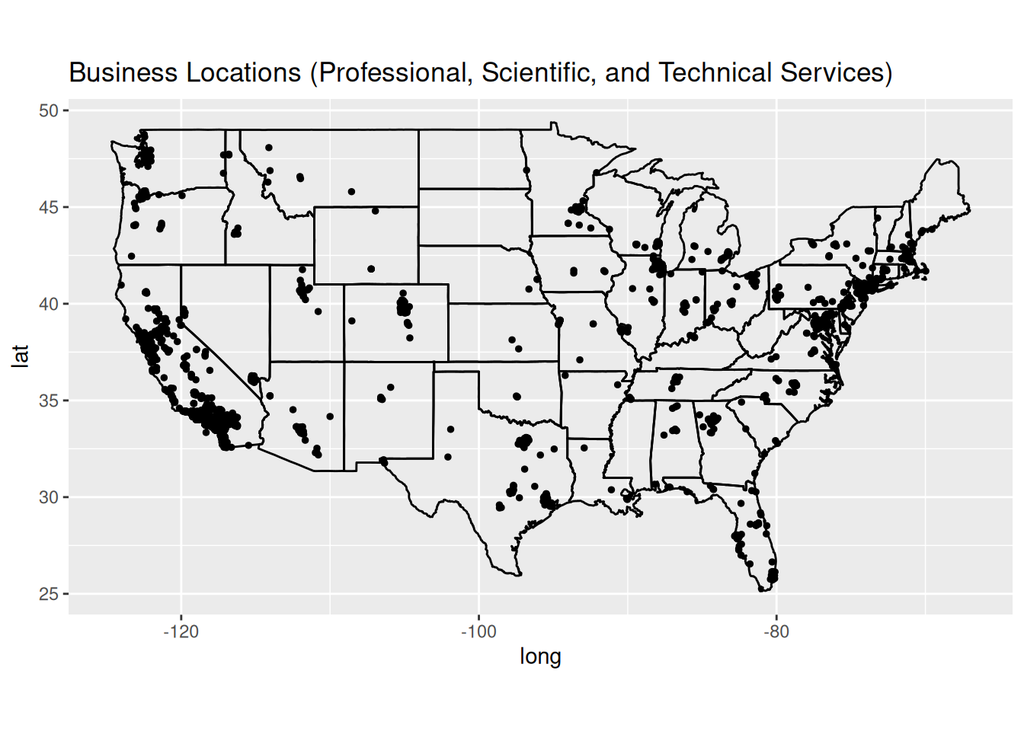

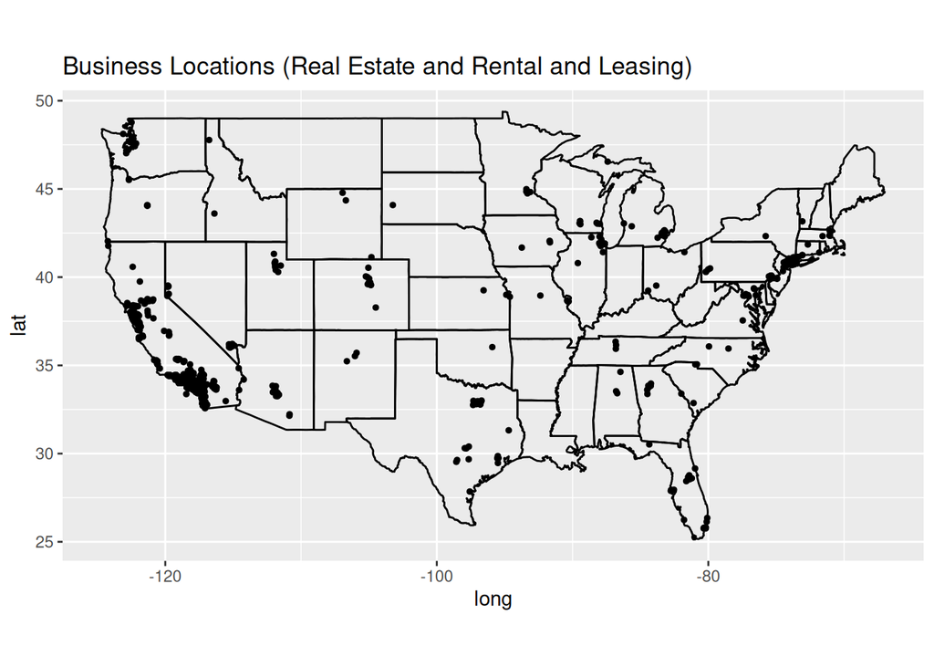

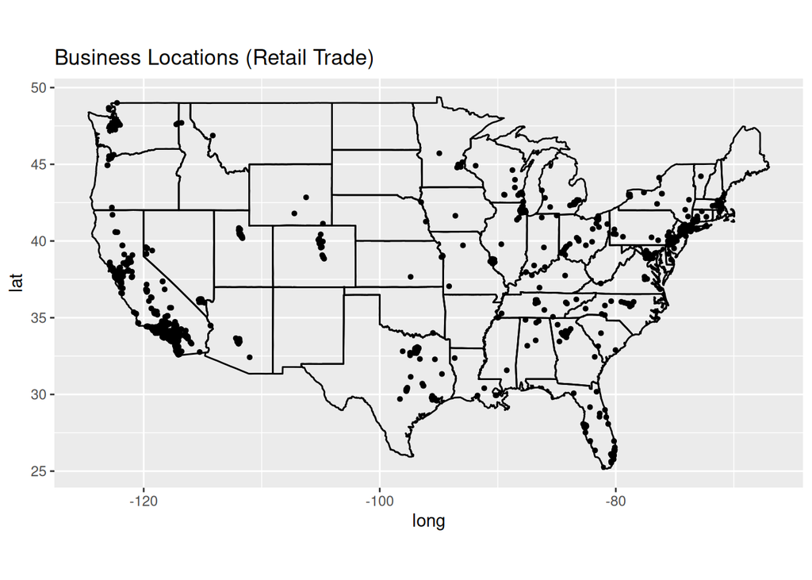

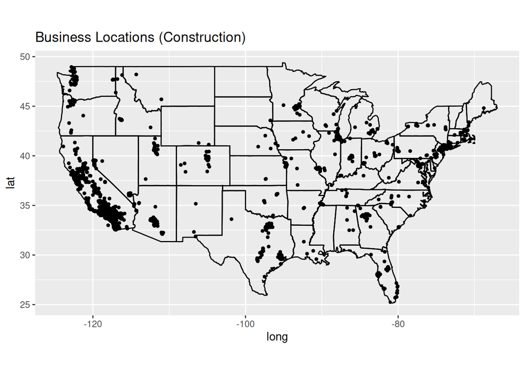

Examining each sector reveals a wide variety of different intriguing possible hypotheses that we may explore, for example:

- Businesses categorized under “Professional, scientific, and technical services” appear to be more evenly spread out geographically, as opposed to the more urban-centric concentration of the other sectors. This may suggest that locational/geographical advantage isn’t as large of a contributing factor to a business’ success compared to other industries. This might be due to a lesser need for logistics, market accessibility, or proximity to customers.
- On the other side of the coin, retail businesses greatly benefit from locational advantage, for the exact opposite reasons stated above. This may explain why they concentrate more to urban metropolises compared to other sectors.
- On a different note, the distribution for construction related businesses seem to be atypical compared to other sectors. While they stay close to urban centers, they don’t concentrate at the exact center, instead preferring to “orbit” them. This could be due to regulatory factors, logistics, etc.

While there are a lot of hypotheses that we can come up with. This set of maps alone is nowhere near sufficient to make any claims or assumptions.

### Top 10 States by Number of Businesses (According to Dataset)

```
## # A tibble: 10 × 2
##    state_name business_count
##    <chr>               <int>
##  1 California         507038
##  2 New York             1095
##  3 Texas                 662
##  4 Florida               435
##  5 Illinois              392
##  6 Arizona               332
##  7 Nevada                321
##  8 Washington            297
##  9 New Jersey            289
## 10 Georgia               285
```

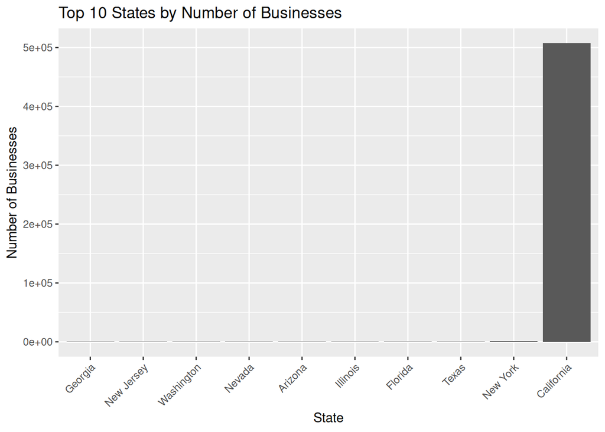

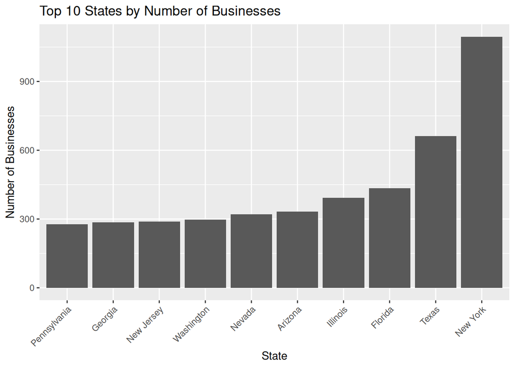

Since this is a California based dataset it will be easy to notice just how many more companies California has compared to the other states. The bar graph shown shows just how large of a margin it is to go from 1st place (California) to 2nd place (New York). Removing California from the bar graph we can then see the margins are much less drastic compared to the other states.

Again, the number of businesses unsurprisingly correlate strongly with the economic strength and vitality of the region, with economic centers like New York and Texas accounting for a large number of businesses out of the total.

### Stacked Barchart Comparing NAICS As Well

[figure not shown]

The distribution of businesses differentiated by sector mostly stays the same between states, except for some noteworthy observations:

- The entertainment sector is disproportionately more developed in New York, *vastly* overshadowing the entertainment sector in other states in terms of size.
- The construction sector is larger in Arizona and Texas compared to other states in terms of proportion, although to a lesser extent compared to the previous observation.

### Top 10 NAICS Descriptions per State (Brian Xicon)

```
## # A tibble: 755 × 3
##    state_name NAICS_Description                                            Count
##    <chr>      <fct>                                                        <int>
##  1 Alabama    Telecommunications                                               5
##  2 Alabama    All other professional, scientific, & technical services         4
##  3 Alabama    All other specialty trade contractors                            4
##  4 Alabama    Commercial & industrial machinery & equipment rental & leas…     2
##  5 Alabama    Computer & software stores                                       2
##  6 Alabama    All other miscellaneous store retailers (including tobacco,…     1
##  7 Alabama    All other personal services                                      1
##  8 Alabama    Apparel mfg.                                                     1
##  9 Alabama    Architectural services                                           1
## 10 Alabama    Building inspection services                                     1
## # ℹ 745 more rows
```

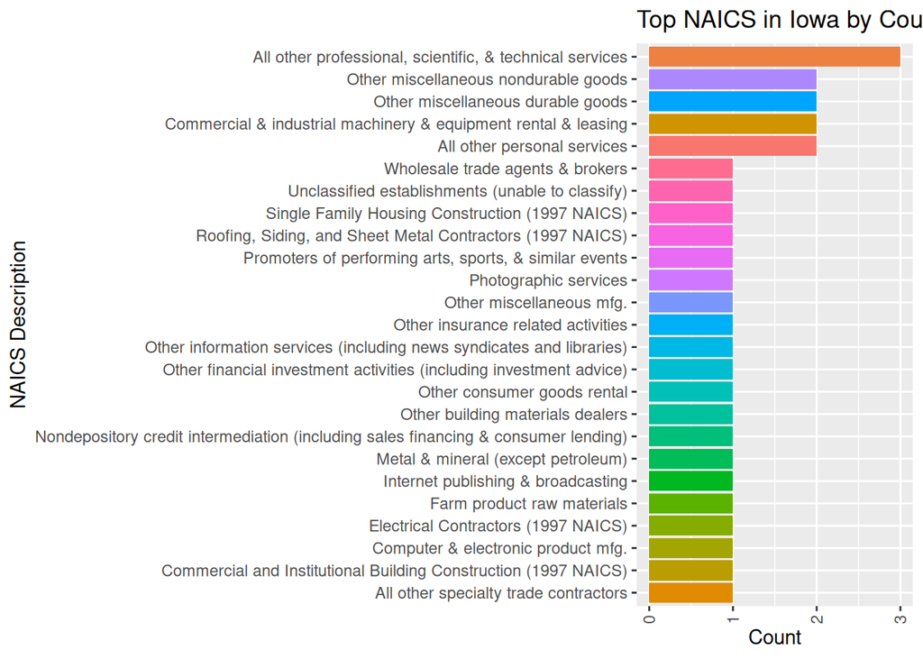

**About the chart:** The bar chart provides a quantitative breakdown of Iowa’s leading industries as defined by the NAICS. With each bar, the chart offers a visual representation of the number of businesses within each NAICS category, making it possible to discover at a glance which sectors are the most prominent in the state.Notably, the professional, scientific, and technical services sector leads the way, with sectors dealing in miscellaneous nondurable and durable goods following closely. This chart is especially useful for anyone keen on understanding the business composition of Iowa. It’s also a valuable resource for investors, as it highlights which industries are most widespread, potentially shedding light on areas of profitability and investment opportunity. It’s worth noting, however, that this data might not fully represent the local Iowa business environment since it’s based on companies headquartered in California.

4. How is the distribution of different business types evolving over time within each council district? Are new industries emerging in specific districts?

[figure not shown]